# Module 1: Professional Communication & Corporate Presence (7.5 Hours)

NOT English Language Learning - This is Business Communication

Author

Global Scholastics

Abstract

Session 2: Writing with clarity under pressure

# Module 1: Session 2 - Writing Under Pressure (2 Hours)

## Complete Facilitator Materials & Student Resources

## **PRE-SESSION SETUP**

### Materials Needed:

- Timer (large, visible - critical for this session)
- Projector for scenario slides
- Printed peer feedback rubrics (1 per student)
- Whiteboard for capturing insights
- Students’ homework from Session 1 (printed)

### Room Setup:

- Tables for pair work
- Clear sightlines to timer
- Space for students to move between groups

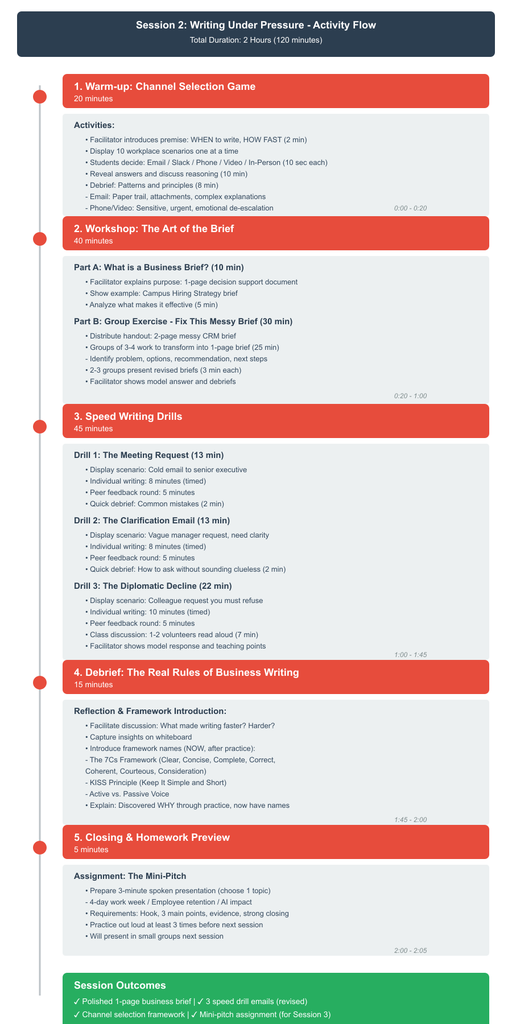

## **WARM-UP: CHANNEL SELECTION GAME (20 minutes)**

### Facilitator Opening:

“Last session was about WHAT to write. Today we’re tackling two harder questions: WHEN to write, and HOW FAST can you do it well?

We’ll start with a game. I’m going to show you 10 workplace situations. For each one, you decide: Should you handle this by Email, Slack/Teams, Phone Call, Video Call, or In-Person meeting? You have 10 seconds to decide.”

### THE SCENARIOS (Display one at a time)

**Scenario 1:** “Your manager asked for last month’s sales figures. You have them ready in an Excel file.”

**Answer:** Email (creates paper trail, attachment needed, no urgency for synchronous discussion)

**Scenario 2:** “Your colleague made a factual error in a presentation that goes to the client in 30 minutes.”

**Answer:** Phone call or Slack (urgent, needs immediate fix, sensitive to correct publicly)

**Scenario 3:** “You need to give your teammate feedback that their recent work quality has declined.”

**Answer:** In-person (or video if remote) - Never over text/email for sensitive personal feedback

**Scenario 4:** “A client just emailed saying they’re unhappy with your team’s responsiveness.”

**Answer:** Phone call first (de-escalate emotionally), then email summary (paper trail of action plan)

**Scenario 5:** “You need to confirm tomorrow’s meeting time with 3 colleagues.”

**Answer:** Slack/Teams (quick, doesn’t need formal email, synchronous responses possible)

**Scenario 6:** “Your vendor is 2 weeks late on a delivery. You need to escalate.”

**Answer:** Email (paper trail essential for accountability, CC relevant stakeholders)

**Scenario 7:** “Your manager just praised your work in front of the team. You want to thank them.”

**Answer:** Brief in-person/Slack (genuine, immediate, not formal enough for email)

**Scenario 8:** “You’re resigning from your position.”

**Answer:** In-person first (out of respect), followed by formal email (official record)

**Scenario 9:** “You need input from 6 team members on which vendor to choose.”

**Answer:** Email with clear deadline (gives people time to think, trackable responses) OR scheduled meeting if decision needed faster

**Scenario 10:** “A client sent a complex technical question that requires a detailed explanation.”

**Answer:** Email (allows you to be precise, client can reference later, you can include screenshots/attachments)

### Debrief Discussion (8 minutes)

After showing all 10, facilitate discussion:

**“What patterns did you notice?”**

Capture answers on whiteboard. Guide toward these principles:

1. **Email when:** You need a paper trail, sending attachments, explaining something complex, no urgency
2. **Slack/Chat when:** Quick coordination, informal check-ins, team already using it actively
3. **Phone/Video when:** Sensitive feedback, potential conflict, emotional de-escalation needed, urgent
4. **In-person when:** Very sensitive topics (firing, resignation, serious feedback), building relationship

**“What’s the biggest mistake you can make?”**

*(Expected answer: Giving negative feedback over email/text - it always goes badly)*

**Real example to share:**

“Last year, a manager at an Indian startup laid off an employee via WhatsApp message. It went viral on Twitter. The company’s reputation was damaged for months. The cost of choosing the wrong channel can be enormous.”

## **WORKSHOP: THE ART OF THE BRIEF (40 minutes)**

### Part 1: What is a Business Brief? (10 minutes)

**Facilitator presents:**

“A brief is a 1-page document designed to help someone make a decision quickly. It’s not a report (which documents what happened) or a proposal (which sells an idea). It’s pure decision support.

You’ll write these constantly in your career: - Should we hire this vendor? - Should we launch this product? - Should we invest in this technology? - Which of three strategies should we pursue?”

**Show example on screen:**

[output not shown]

**Analyze together (5 minutes):**

“What makes this brief effective?” - Opens with the recommendation (not buried at the end) - Uses headers to make it scannable - Quantifies everything (percentages, rupees, dates) - Addresses objections proactively (Risks section) - Makes it easy to say yes (clear next steps) - Specifies decision deadline

### Part 2: Group Exercise - Fix This Messy Brief (30 minutes)

**Facilitator distributes handout:**

“You’re going to receive a 2-page brief that’s poorly written. Your job: Work in groups of 3-4 to convert it into a tight 1-page brief that actually helps someone make a decision.”

### HANDOUT: The Messy Brief (distribute printed copies)

[output not shown]

### Group Task Instructions (25 minutes working time):

**Display on screen:**

“Transform this into a 1-page brief that answers: 1. What’s the problem? (Quantify it) 2. What are the real options? (Max 3) 3. What do you recommend and why? 4. What’s the next step?

You have 25 minutes. One person from your group will present your brief.”

### Facilitator walks around during group work, giving guidance:

- “Where’s your recommendation? Should be in the first paragraph.”
- “You’re listing 5 options. Pick the top 2-3 and explain why you eliminated the others.”
- “Quantify the problem: How much time is wasted? How much revenue is at risk?”

- 2-3 groups present their revised briefs (3 minutes each)
- Class provides feedback
- Facilitator highlights what worked

### Facilitator shows model answer:

[output not shown]

**Debrief:**

“Notice how every vague statement from the original became specific: - ‘System is slow’ → ‘30-45 second load times’ - ‘Some options out there’ → ‘Evaluated 5, recommend Zoho’ - ‘Cost is something to think about’ → ‘₹12L investment, ₹36L annual productivity gain’ - ‘Maybe we should do something?’ → ‘Replace by June 1’

A brief forces you to do the hard thinking so your manager doesn’t have to.”

## **SPEED WRITING DRILLS (45 minutes)**

### Facilitator Setup:

“Now we’re going to practice writing under real workplace pressure. In most jobs, you don’t have hours to craft perfect emails. You have minutes. We’re going to simulate that.”

### DRILL 1: The Meeting Request (8 minutes writing + 5 min feedback)

**Display scenario:**

```
SITUATION:
You are Sneha Patel, Marketing Coordinator at FinTech Solutions India.

Your manager asked you to set up a meeting with Rajiv Malhotra, the Chief Digital Officer at a potential client company (IndusBank). Your manager wants to pitch IndusBank on your company's new digital banking platform.

CHALLENGE:
- You've never met Rajiv
- You only have his email (found on LinkedIn)
- He's very senior (C-suite) and presumably very busy
- You need a 45-minute meeting in the next 2 weeks
- Your manager wants you to handle this (not send it from her email)

TASK:
Write the email requesting this meeting. Make it compelling enough that he actually responds.

TIME LIMIT: 8 MINUTES. START NOW.
```

**Students write in silence. Timer visible.**

### Peer Feedback Round (5 minutes)

**Instructions:**

“Exchange with your neighbor. Read their email and answer: 1. Would a busy executive actually read this? 2. Is the value proposition clear? (Why should he meet with you?) 3. Is it easy to say yes? (Specific time options? Clear duration?)

Write 1-2 sentences of feedback at the bottom.”

### Quick Debrief (2 minutes)

“Who got feedback that their email was too long? (hands up) Who was told their value proposition was unclear? (hands up)

Common mistake: We focus on US (‘We’re a leading fintech company…’) instead of THEM (‘Your digital transformation roadmap needs…’)”

### DRILL 2: The Clarification Email (8 minutes writing + 5 min feedback)

**Display scenario:**

```
SITUATION:
You are Karan Desai, Junior Data Analyst.

This morning your manager sent you this Slack message:
"Karan - can you pull together that customer analysis we discussed and send it to the product team? They need it for planning."

PROBLEM:
You have NO IDEA what she's talking about. You discussed three different customer analyses in the past month:
1. Customer churn analysis (you finished this 2 weeks ago)
2. Customer segmentation by demographics (still in progress, 60% done)
3. Customer feedback sentiment analysis (hasn't been started yet)

You don't know:
- Which analysis she means
- When the product team needs it
- What level of detail they want (summary vs. full dataset)
- Who specifically on the product team should receive it

TASK:
Write an email asking for clarification WITHOUT sounding clueless or unprepared. Show that you've thought about this, you just need specific direction.

TIME LIMIT: 8 MINUTES. START NOW.
```

### Peer Feedback Round (5 minutes)

Same process as Drill 1.

### Quick Debrief (2 minutes)

“This is one of the hardest emails to write. You need to: - Show you’re competent (not just saying ‘I don’t understand’) - Ask specific questions (not open-ended ‘What do you want?’) - Offer a plan pending her input (showing initiative)

Bad: ‘Hi, I’m not sure which analysis you mean?’ Good: ‘Hi, I want to make sure I send the right analysis. We have three customer projects in flight. Could you confirm: are you referring to the churn analysis (completed) or the demographic segmentation (in progress)? Also, what’s the deadline for the product team?’”

### DRILL 3: The Diplomatic Decline (10 minutes writing + 5 min feedback)

**Display scenario:**

```
SITUATION:
You are Pooja Reddy, Content Writer at a digital marketing agency.

Your colleague Arjun (from the design team) just Slacked you:
"Hey Pooja! Can you write social media captions for this campaign I'm working on? Client needs it by Friday. Probably like 15-20 posts? Thanks!!"

PROBLEM:
- You're already overloaded (working on 3 active client campaigns)
- This isn't your project (you weren't assigned to this client)
- Arjun didn't go through proper channels (should have asked your manager to assign you)
- He's underestimating the work (15-20 posts = 4-5 hours minimum)
- But Arjun is a nice person and you don't want to damage the relationship

TASK:
Decline this request professionally. Don't say yes (you genuinely cannot). Don't be rude (you work with Arjun regularly). Suggest an alternative solution if possible.

TIME LIMIT: 10 MINUTES. START NOW.
```

### Peer Feedback Round (5 minutes)

### Class Discussion (7 minutes)

**Facilitator asks for 1-2 volunteers to read their responses aloud.**

After each, discuss: - Did they say no clearly? - Did they maintain the relationship? - Did they suggest an alternative?

**Model Response:**

```
Hey Arjun!

I'd love to help, but I'm at capacity this week with three client campaigns (deadlines Thursday and Friday). I won't be able to deliver quality work on social captions by Friday.

Two suggestions:
1. Check with Priya (she mentioned having lighter load this week)
2. If timeline is flexible, I could potentially take this on next week

If it's urgent and Priya's not available, you might want to loop in Kavita (our manager) to see if priorities can be reshuffled.

Good luck with the campaign!
```

**Teaching Point:**

“The art of saying no: 1. Say no clearly (don’t hint, don’t maybe) 2. Give a brief reason (but don’t over-apologize) 3. Offer an alternative (show you care about the problem) 4. Maintain warmth (relationship matters)

Notice: No ‘I’m so sorry!!’ No ‘I feel terrible!’ Just clear, kind, professional.”

## **DEBRIEF: THE REAL RULES OF BUSINESS WRITING (15 minutes)**

### Facilitator leads reflection:

“Let’s capture what you learned from writing under pressure today.”

**Facilitate discussion, capturing on whiteboard:**

**Question 1: “What made writing faster for you in these drills?”**

Expected answers (guide toward these): - Having a clear structure in mind - Knowing my main point before I started - Not trying to be perfect, just clear - Using bullets instead of long paragraphs

**Question 2: “What made writing harder?”**

Expected answers: - Not enough information (the clarification scenario) - Balancing politeness with directness (the decline scenario) - Figuring out the right tone (formal vs. casual)

**Question 3: “What’s different between how you wrote emails before this course vs. now?”**

Expected answers: - I used to bury my main point - I was too worried about being polite - I wrote way too much

### Facilitator Introduces Framework Names (NOW, not earlier)

“Everything you’ve been practicing has names. Let me give you the labels:

**The 7Cs Framework** (write on board): 1. **Clear** - main point obvious 2. **Concise** - no wasted words 3. **Complete** - includes all necessary info 4. **Correct** - grammar, facts accurate 5. **Coherent** - logical flow 6. **Courteous** - respectful tone 7. **Consideration** - adapted to your reader

**The KISS Principle:** Keep It Simple and Short

**Active vs. Passive Voice:** Active: ‘I completed the report’ (direct, confident) Passive: ‘The report was completed’ (vague, weak)

You’ve been using these all day. Now you have names for them.”

**Why we taught it this way:**

“If I’d started Session 1 by saying ‘Today we’re learning the 7Cs,’ you would have memorized them and forgotten them. Instead, you discovered WHY they matter by actually writing. The frameworks are just shortcuts to remember what you already learned through practice.

This is the difference between academic learning and professional training.”

## **CLOSING & HOMEWORK PREVIEW (5 minutes)**

### Homework for Next Session:

**Display on screen:**

“Before Session 3, complete this assignment:

**Assignment: The Mini-Pitch**

Prepare a 3-minute spoken presentation on ONE of these topics:

1. Why our company should adopt a 4-day work week
2. The best way to improve employee retention in Indian IT companies
3. How AI will change [your field] in the next 5 years

Requirements: - Opening hook (grab attention in first 10 seconds) - Clear structure (3 main points maximum) - Evidence to support your argument (data, examples, expert opinions) - Strong closing (call to action or key takeaway) - Practice OUT LOUD at least 3 times before class

You’ll present this in small groups next session. This is about SPEAKING skills—confident delivery, clear voice, eye contact.”

### Facilitator Closing:

“Today you learned that professional writing is about speed AND quality. In the real world, you need both. The more you practice writing in structured ways, the faster you’ll get.

Key takeaway: **Clarity is kindness.** When you write clearly, you respect your reader’s time. When you write vaguely, you force them to do extra work. Be the colleague who makes other people’s jobs easier, not harder.

See you next session for speaking and presenting.”

## **FACILITATOR NOTES & TEACHING TIPS**

### Time Management:

- Speed drills are the heart of this session—don’t cut them short
- If Channel Selection Game runs long, skip 1-2 scenarios
- If groups struggle with brief exercise, give them a template structure

### Common Student Challenges:

1. **Panic during timed writes:** Remind them this is practice, not evaluation
2. **Too polite to say no:** Role-model firm-but-kind declines
3. **Asking for extensions on drills:** Don’t give them. Real deadlines don’t extend.

### Assessment Signals:

Watch for students who: - ✅ Start emails with the main point - ✅ Use specific details (numbers, dates, names) - ✅ Anticipate reader questions - ❌ Still writing 3 paragraphs before getting to the point - ❌ Using vague language (“soon,” “some,” “around”)

### Energy Management:

Speed drills are intense. Give 2-minute standing breaks between drills.

## **HANDOUTS TO PRINT**

### Handout 1: Channel Selection Scenarios (all 10 situations on one page)

### Handout 2: The Messy CRM Brief (full text, 2 pages)

### Handout 3: Speed Drill Scenarios (all 3 scenarios on one page for reference)

### Handout 4: Homework Assignment Sheet (mini-pitch requirements)

**END OF SESSION 2 MATERIALS**